# Assignment 3

Sebastian Bravo

April 8, 2022

# Animal Bites in Louisville Kentucky 1985 - 2017

## by Sebastian Bravo

### Dataset Source: https://www.kaggle.com/datasets/rtatman/animal-bites

## Information on Dataset

This analysis is based off of a dataset obtained from Kaggle titled *Animal Bites*. The context of this dataset is that it was collected based on reports of bites to law enforcement as therre is a concern for rabies in animal bites. This data set is on over 9,000 animal bites that occurred near Louisville, Kentucky in the time period of 1985 - 2017. For more information on this dataset the link to it is [here](https://www.kaggle.com/datasets/rtatman/animal-bites).

**Importing Libraries**

We will be making use of dplyr and ggplot2 to do the analysis on this dataset, so we will need to install and import these libraries first and foremost.

```r
library(dplyr)
```

```r
library(ggplot2)
library(forcats) #So I can reorder bar plots by length
```

**Importing data**

We will import the .csv file from the working directory and quickly clean some of the data as there are blanks that were chosen to be left blank when certain information was not known. These blank values will have their value changed to “N/A”, but might also be changed to UNKNOWN in the future where applicable.

```r
Rabies<-read.csv("Health_AnimalBites.csv")
Rabies[Rabies==""] <- "N/A"
head(Rabies)
```

```
##             bite_date SpeciesIDDesc BreedIDDesc GenderIDDesc      color
## 1 1985-05-05 00:00:00           DOG         N/A       FEMALE LIG. BROWN
## 2 1986-02-12 00:00:00           DOG         N/A      UNKNOWN  BRO & BLA
## 3 1987-05-07 00:00:00           DOG         N/A      UNKNOWN        N/A
## 4 1988-10-02 00:00:00           DOG         N/A         MALE  BLA & BRO
## 5 1989-08-29 00:00:00           DOG         N/A       FEMALE    BLK-WHT
## 6 1989-11-24 00:00:00           DOG         N/A      UNKNOWN        N/A
##   vaccination_yrs    vaccination_date victim_zip AdvIssuedYNDesc
## 1               1 1985-06-20 00:00:00      40229              NO
## 2              NA                 N/A      40218              NO
## 3              NA                 N/A      40219              NO
## 4              NA                 N/A        N/A              NO
## 5              NA                 N/A        N/A              NO
## 6              NA                 N/A      40211              NO
##   WhereBittenIDDesc     quarantine_date DispositionIDDesc head_sent_date
## 1              BODY 1985-05-05 00:00:00           UNKNOWN            N/A
## 2              BODY 1986-02-12 00:00:00           UNKNOWN            N/A
## 3              BODY 1990-05-07 00:00:00           UNKNOWN            N/A
## 4              BODY 1990-10-02 00:00:00           UNKNOWN            N/A
## 5              BODY                 N/A           UNKNOWN            N/A
## 6              BODY                 N/A           UNKNOWN            N/A
##   release_date ResultsIDDesc
## 1          N/A       UNKNOWN
## 2          N/A       UNKNOWN
## 3          N/A       UNKNOWN
## 4          N/A       UNKNOWN
## 5          N/A       UNKNOWN
## 6          N/A       UNKNOWN
```

# Analysis

As the dataset contains information such as type of animal that caused the bite, breed if it’s a dog, track the amount of bites year by year, as well as get an understanding of the proportion of bites that are later tested positive for Rabies. We can quickly construct a table and a bar plot to see which animals have the most reported bites in this time period and area.

```r
Rabies$SpeciesIDDesc[Rabies$SpeciesIDDesc==""] <- "UNKNOWN" #Here is an example where having N/A as Unknown makes sense
Rabies %>%
  group_by(Rabies$SpeciesIDDesc) %>%
  summarize(Count=n()) %>%
  arrange(desc(Count))
```

```
## # A tibble: 10 x 2
##    `Rabies$SpeciesIDDesc` Count
##    <chr>                  <int>
##  1 DOG                     7029
##  2 CAT                     1568
##  3 BAT                      237
##  4 N/A                      118
##  5 RACCOON                   27
##  6 OTHER                     11
##  7 HORSE                      5
##  8 FERRET                     4
##  9 RABBIT                     3
## 10 SKUNK                      1
```

Now we construct the bar chart to display this in a more digestible medium

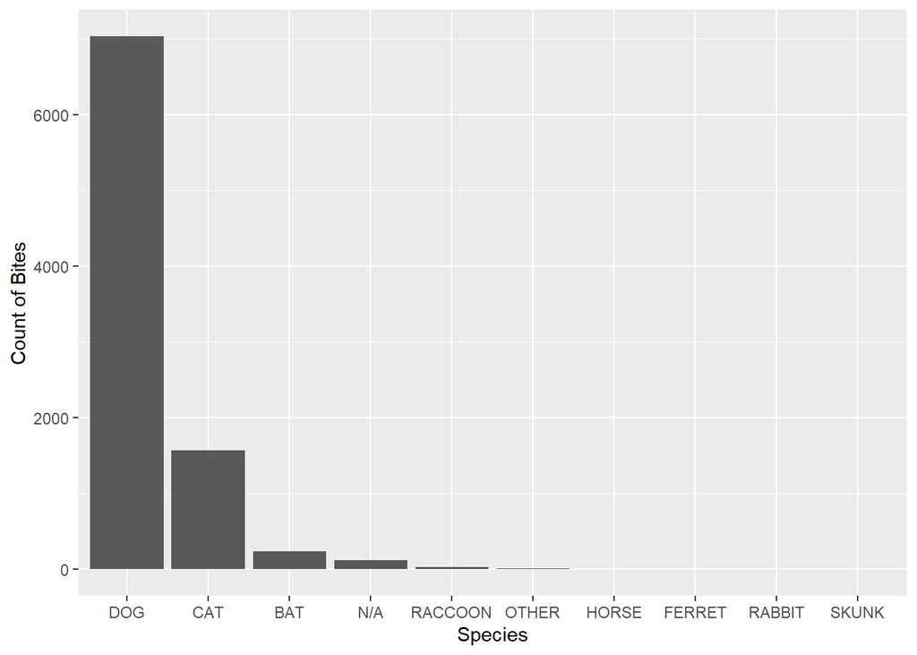

```
We can see immediately that the vast amount of bites come from domesticated animals. Dogs have a total of 7029 bites, followed by cats at 1568 bites. After that however, it is observable that the wild animal with the most bites are bats at 237
```

```r
Rabies %>%
  ggplot(aes(x = fct_infreq(SpeciesIDDesc))) +
  geom_bar() +
  labs(x ="Species") +
  labs(y = "Count of Bites")
```

With these findings we should focus more on Dog, Cat, and Bat bites. But before we jump into that we should track the total number of bites and rabies cases on a year to year basis through a line plot.

### Bites and Rabies Cases year by year

```r
Rabies$bite_date <- as.Date(Rabies$bite_date) ###Need to change the data type of this column to date in order to create a new one for Year
Rabies[, "Year"] <- format(Rabies[, "bite_date"], "%Y")

Yearly_Count <- Rabies %>%  #Unique Dataset for the line graph
  count(Year,SpeciesIDDesc)

Yearly_Count$Year <- as.integer(Yearly_Count$Year) # Parse Year as Integer

Yearly_Count <- filter(Yearly_Count, Year >= 1985 & Year <= 2017)
Yearly_Count <- filter(Yearly_Count, SpeciesIDDesc == "DOG" | SpeciesIDDesc == "CAT" | SpeciesIDDesc == "BAT") #Further filtering this dataset by year and species
```

The first part of this process is to organize the dataset a bit by deriving a new column of year to the dataset using the “Bite_Date” columnn. However the “Bite_Date” column needs to be parsed as a date type first as it was originally just a string. Once this is done and we have our new Year Column a new subsection of the dataset was created to count the occurrences of bites per year by animal. This data was further filtered to be between the years of 1985 to 2017 (inclusive) as there were a few null values, and then further filtered to only show Dog, Cat, and Bat bites as we previously noted that these were the most significant

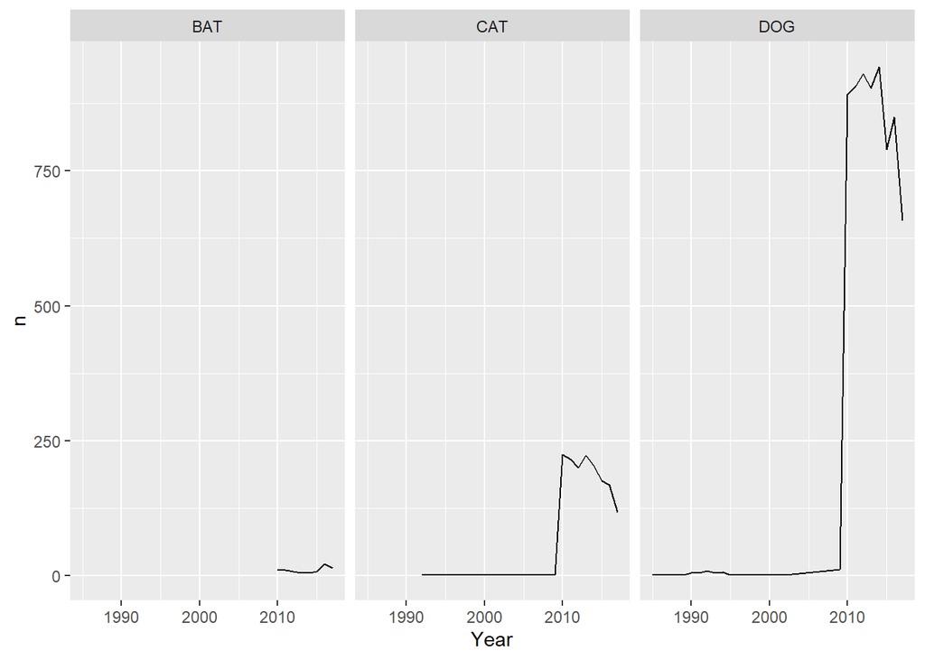

```r
ggplot(data = Yearly_Count, aes(x = Year, y = n)) +
  geom_line() +
  facet_wrap(facets = vars(SpeciesIDDesc))
```

Faceted line plots are generated for the three species we want to analyze. What we can immediately see is that bites appear to increase substantially from 2010 onwards. However, this seems like when more people reported bites to animal control or the police department. From that point onward we can see that the trend goes downward from that point onward. Now that we have this lets look at the proportion of bites that were tested to be related to Rabies.

### Proportion of Bites Associated with Rabies

```r
Rabies <- filter(Rabies, SpeciesIDDesc == "DOG" | SpeciesIDDesc == "CAT" | SpeciesIDDesc == "BAT") #Filtering the main dataset by the same three species

Rabies$ResultsIDDesc[Rabies$ResultsIDDesc=="N/A"] <- "UNKNOWN"

CountRabiesStatus <- Rabies %>% #Create a new dataset for stacked column chart with percentages
  count(SpeciesIDDesc,ResultsIDDesc) %>%   #Count by Species and then by Test Results
  mutate(pct=n/sum(n))
```

The first thing to do in this case is to filter our dataset by the three species we are focusing in on. As we want to see the amount of cases in proportion to the total of these three were associated with a positive test for Rabies - as denoted in the “ResultsIDDesc” column. However, there is a significant amount of Unknown values, implying that not all bites were tested for rabies. We first make a nother subsection of our dataset to make this plot using a count of Species and Results and then adding another column “Pct” for the percentage.

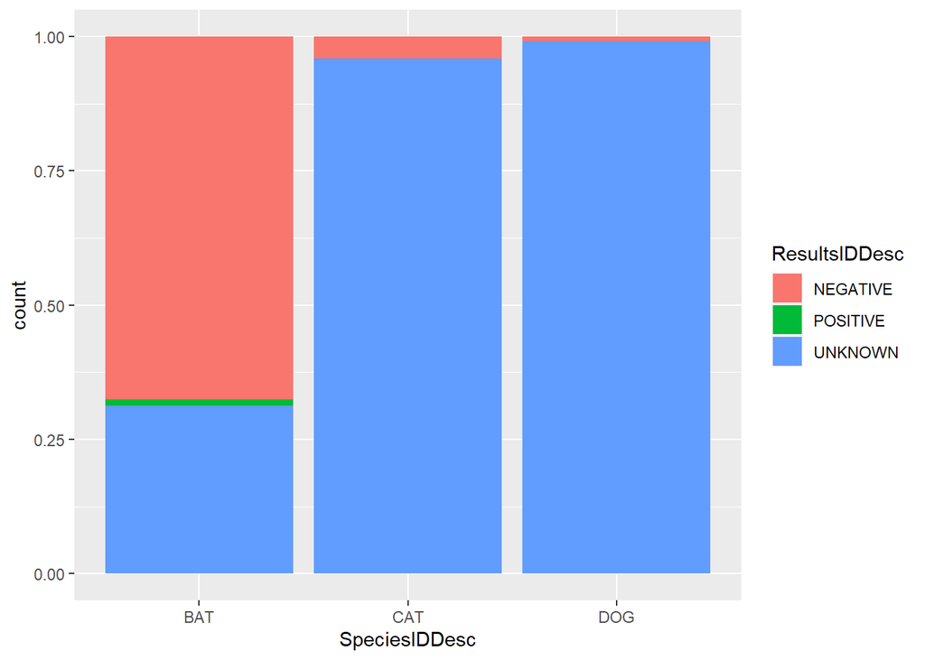

```r
ggplot(Rabies, aes(x=SpeciesIDDesc, fill=ResultsIDDesc)) +
  geom_bar (position = "fill")
```

This means that most bites don’t spread Rabies in the modern world in Louisville. Finally the last thing I want to analyze are the type of breeds of Dogs that account for most Dog bites.

### Dog Bites by Breed

```r
BreedBites <- Rabies %>% #Create a new subsection for breeds
  filter(SpeciesIDDesc == "DOG") %>% #Filter to only have Dog Bites
  group_by(BreedIDDesc) %>%
  summarize(Count=n()) %>%
  arrange(desc(Count)) %>%
  mutate(pct = (Count/sum(Count))*100)

BreedBites
```

```
## # A tibble: 102 x 3
##    BreedIDDesc     Count   pct
##    <chr>           <int> <dbl>
##  1 N/A              3274 46.6
##  2 PIT BULL         1101 15.7
##  3 GERM SHEPHERD     327  4.65
##  4 LABRADOR RETRIV   253  3.60
##  5 BOXER             181  2.58
##  6 CHICHAUHUA        165  2.35
##  7 SHIH TZU          119  1.69
##  8 BEAGLE            115  1.64
##  9 ROTTWEILER         86  1.22
## 10 AAUST. TERR.       78  1.11
## # ... with 92 more rows
```

Breaking down the amount of dog bites reveals some immediately interesting information. Barring the fact that most dog breeds are N/A - not reported or not known, Pit Bull has the most out of known breeds accounting for 15.7% of Dog Bites. The next breed of dog that accounts for most bites are German Shephards at 4.65% this is a huge difference in proportionality between the two breeds as the rest of the breeds in the top 10 cluster together. It does generally align with common sentiment that the Pit Bull is classified as a more “aggressive” breed of dog.

### This is the end of the report, last updated 2022-04-08